# Gene expresson course. Task 1. Microarrays analysis.

## Homework 1: *deadline November 21st*

The first homework is to analyze a microarray gene expression dataset. All the datasets will be available by GEO id, so you can find them at GEO omnibus and also use `GEOquery::getGEO("GSEXXXXX")` to get the expression data into R session.

Basically you needed to perform basic steps for a dataset: normalize and make sense of the PCA plot. Then you need to design differential expression to address the general question for your homework. Once you perform DE I want you to highlight genes that are different and perform pathway enrichment.

**My dataset**: `GSE30854`

**Short info**: Fecal microbial infusion from lean donors increases insulin sensitivity in subjects with metabolic syndrome

Organism: Homo sapiens

Experiment type: Expression profiling by array

Full information [here](https://www.ncbi.nlm.nih.gov/geo/query/acc.cgi?acc=GSE30854)

My question: `Do autologous and allogenic patients respond differently to treatment?`.

The platform is quite good, it was used for analysing 25745 samples.

#№# Importing libraries

```r
library(GEOquery)
library(Biobase)
library(ggplot2)
library(reshape2)
library(limma)
library(MASS)
library(data.table)
library(sva)
library(pheatmap)
library(RColorBrewer)
library(ggrepel)
library(dplyr)
library(fgsea)
```

## Preprocessing

### Loading the dataset

```r
data <- getGEO("GSE30854", AnnotGPL = TRUE)[[1]]
head(pData(data))
```

|  | title | geo_accession | status | submission_date | last_update_date | type | channel_count | source_name_ch1 | organism_ch1 | characteristics_ch1 | characteristics_ch1.1 | characteristics_ch1.2 | characteristics_ch1.3 | characteristics_ch1.4 | treatment_protocol_ch1 | growth_protocol_ch1 | molecule_ch1 | extract_protocol_ch1 | label_ch1 | label_protocol_ch1 | taxid_ch1 | hyb_protocol | scan_protocol | description | description.1 | data_processing | platform_id | contact_name | contact_email | … |
| --- | --- | --- | --- | --- | --- | --- | --- | --- | --- | --- | --- | --- | --- | --- | --- | --- | --- | --- | --- | --- | --- | --- | --- | --- | --- | --- | --- | --- | --- | --- |
| GSM765503 | Autologous_6wk (5370916043_A) | GSM765503 | Public on Oct 28 2020 | Jul 21 2011 | Oct 28 2020 | RNA | 1 | Intestinal jejunal biopsie | Homo sapiens | fecal microbial transplant type: Autologous | sample id: patient16 | disease state: Obese | gender: Males | Stage: Treatment | Male subjects with metabolic syndrome underwent bowel lavage and were randomised to allogenic (from male lean donors with BMI<23 kg/m2, n=9) or autologous (reinfusion of own feces, n=9) fecal microbia… |  | total RNA | Total RNA was extracted with TriReagent (Sigma, St. Louis, MO, USA). The quality and concentration of the RNA were determined using the Experion automated electrophoresis system (Bio-Rad Laboratories,… | Biotin | Biotinylated cRNA were prepared with the Illumina TotalPrep RNA Amplification Kit ( Applied Biosystems) | 9606 | Standard Illumina hybridization protocol | Standard Illumina scanning protocol | 5370916043_A |  | Quantile Normalized and corrected for intra-experimental variation (Combat) generating robust gene-expression profiles (pubmed: 20181233). | GPL6947 | vincent,,bloks | v.w.bloks@umcg.nl | … |
| GSM765504 | Autologous_0wk (5370916043_B) | GSM765504 | Public on Oct 28 2020 | Jul 21 2011 | Oct 28 2020 | RNA | 1 | Intestinal jejunal biopsie | Homo sapiens | fecal microbial transplant type: Autologous | sample id: patient10 | disease state: Obese | gender: Males | Stage: Basal | Male subjects with metabolic syndrome underwent bowel lavage and were randomised to allogenic (from male lean donors with BMI<23 kg/m2, n=9) or autologous (reinfusion of own feces, n=9) fecal microbia… |  | total RNA | Total RNA was extracted with TriReagent (Sigma, St. Louis, MO, USA). The quality and concentration of the RNA were determined using the Experion automated electrophoresis system (Bio-Rad Laboratories,… | Biotin | Biotinylated cRNA were prepared with the Illumina TotalPrep RNA Amplification Kit ( Applied Biosystems) | 9606 | Standard Illumina hybridization protocol | Standard Illumina scanning protocol | 5370916043_B |  | Quantile Normalized and corrected for intra-experimental variation (Combat) generating robust gene-expression profiles (pubmed: 20181233). | GPL6947 | vincent,,bloks | v.w.bloks@umcg.nl | … |
| GSM765505 | Autologous_0wk (5370916043_C) | GSM765505 | Public on Oct 28 2020 | Jul 21 2011 | Oct 28 2020 | RNA | 1 | Intestinal jejunal biopsie | Homo sapiens | fecal microbial transplant type: Autologous | sample id: patient23 | disease state: Obese | gender: Males | Stage: Basal | Male subjects with metabolic syndrome underwent bowel lavage and were randomised to allogenic (from male lean donors with BMI<23 kg/m2, n=9) or autologous (reinfusion of own feces, n=9) fecal microbia… | Autologous_0wk | total RNA | Total RNA was extracted with TriReagent (Sigma, St. Louis, MO, USA). The quality and concentration of the RNA were determined using the Experion automated electrophoresis system (Bio-Rad Laboratories,… | Biotin | Biotinylated cRNA were prepared with the Illumina TotalPrep RNA Amplification Kit ( Applied Biosystems) | 9606 | Standard Illumina hybridization protocol | Standard Illumina scanning protocol | 5370916043_C |  | Quantile Normalized and corrected for intra-experimental variation (Combat) generating robust gene-expression profiles (pubmed: 20181233). | GPL6947 | vincent,,bloks | v.w.bloks@umcg.nl | … |
| GSM765506 | Allogenic_0wk (5370916043_D) | GSM765506 | Public on Oct 28 2020 | Jul 21 2011 | Oct 28 2020 | RNA | 1 | Intestinal jejunal biopsie | Homo sapiens | fecal microbial transplant type: Allogenic | sample id: patient12 | disease state: Obese | gender: Males | Stage: Basal | Male subjects with metabolic syndrome underwent bowel lavage and were randomised to allogenic (from male lean donors with BMI<23 kg/m2, n=9) or autologous (reinfusion of own feces, n=9) fecal microbia… |  | total RNA | Total RNA was extracted with TriReagent (Sigma, St. Louis, MO, USA). The quality and concentration of the RNA were determined using the Experion automated electrophoresis system (Bio-Rad Laboratories,… | Biotin | Biotinylated cRNA were prepared with the Illumina TotalPrep RNA Amplification Kit ( Applied Biosystems) | 9606 | Standard Illumina hybridization protocol | Standard Illumina scanning protocol | 5370916043_D |  | Quantile Normalized and corrected for intra-experimental variation (Combat) generating robust gene-expression profiles (pubmed: 20181233). | GPL6947 | vincent,,bloks | v.w.bloks@umcg.nl | … |
| GSM765507 | Autologous_6wk (5370916043_E) | GSM765507 | Public on Oct 28 2020 | Jul 21 2011 | Oct 28 2020 | RNA | 1 | Intestinal jejunal biopsie | Homo sapiens | fecal microbial transplant type: Autologous | sample id: patient10 | disease state: Obese | gender: Males | Stage: Treatment | Male subjects with metabolic syndrome underwent bowel lavage and were randomised to allogenic (from male lean donors with BMI<23 kg/m2, n=9) or autologous (reinfusion of own feces, n=9) fecal microbia… |  | total RNA | Total RNA was extracted with TriReagent (Sigma, St. Louis, MO, USA). The quality and concentration of the RNA were determined using the Experion automated electrophoresis system (Bio-Rad Laboratories,… | Biotin | Biotinylated cRNA were prepared with the Illumina TotalPrep RNA Amplification Kit ( Applied Biosystems) | 9606 | Standard Illumina hybridization protocol | Standard Illumina scanning protocol | 5370916043_E |  | Quantile Normalized and corrected for intra-experimental variation (Combat) generating robust gene-expression profiles (pubmed: 20181233). | GPL6947 | vincent,,bloks | v.w.bloks@umcg.nl | … |
| GSM765508 | Autologous_0wk (5370916043_F) | GSM765508 | Public on Oct 28 2020 | Jul 21 2011 | Oct 28 2020 | RNA | 1 | Intestinal jejunal biopsie | Homo sapiens | fecal microbial transplant type: Autologous | sample id: patient17 | disease state: Obese | gender: Males | Stage: Basal | Male subjects with metabolic syndrome underwent bowel lavage and were randomised to allogenic (from male lean donors with BMI<23 kg/m2, n=9) or autologous (reinfusion of own feces, n=9) fecal microbia… |  | total RNA | Total RNA was extracted with TriReagent (Sigma, St. Louis, MO, USA). The quality and concentration of the RNA were determined using the Experion automated electrophoresis system (Bio-Rad Laboratories,… | Biotin | Biotinylated cRNA were prepared with the Illumina TotalPrep RNA Amplification Kit ( Applied Biosystems) | 9606 | Standard Illumina hybridization protocol | Standard Illumina scanning protocol | 5370916043_F |  | Quantile Normalized and corrected for intra-experimental variation (Combat) generating robust gene-expression profiles (pubmed: 20181233). | GPL6947 | vincent,,bloks | v.w.bloks@umcg.nl | … |

```r
geo_data <- data
```

### Filtering pData

```r
colnames(pData(geo_data))
```

```
##  [1] "title"                               "geo_accession"
##  [3] "status"                              "submission_date"
##  [5] "last_update_date"                    "type"
##  [7] "channel_count"                       "source_name_ch1"
##  [9] "organism_ch1"                        "characteristics_ch1"
## [11] "characteristics_ch1.1"               "characteristics_ch1.2"
## [13] "characteristics_ch1.3"               "characteristics_ch1.4"
## [15] "treatment_protocol_ch1"              "growth_protocol_ch1"
## [17] "molecule_ch1"                        "extract_protocol_ch1"
## [19] "label_ch1"                           "label_protocol_ch1"
## [21] "taxid_ch1"                           "hyb_protocol"
## [23] "scan_protocol"                       "description"
## [25] "description.1"                       "data_processing"
## [27] "platform_id"                         "contact_name"
## [29] "contact_email"                       "contact_laboratory"
## [31] "contact_department"                  "contact_institute"
## [33] "contact_address"                     "contact_city"
## [35] "contact_zip/postal_code"             "contact_country"
## [37] "supplementary_file"                  "data_row_count"
## [39] "disease state:ch1"                   "fecal microbial transplant type:ch1"
## [41] "gender:ch1"                          "sample id:ch1"
## [43] "Stage:ch1"
```

```r
pData(geo_data) <- pData(geo_data)[, c("title","geo_accession", "fecal microbial transplant type:ch1", "sample id:ch1","disease state:ch1", "Stage:ch1", "description")]
pData(geo_data) <- cbind(pData(geo_data), transpose(strsplit(pData(geo_data)[, c("title")], " ")))
pData(geo_data) <- pData(geo_data)[,1:(length(pData(geo_data))-1)]
colnames(pData(geo_data)) <- c("title", "geo", "type",  "sample_id",  "disease", "stage", "description", "experiment")

pData(geo_data)$sample_id <- gsub("Tech_replicate_","",pData(geo_data)$sample_id)

pData(geo_data)$sample_id <- gsub("_","",pData(geo_data)$sample_id)

head(pData(geo_data))
```

|  | title | geo | type | sample_id | disease | stage | description | experiment |
| --- | --- | --- | --- | --- | --- | --- | --- | --- |
| GSM765503 | Autologous_6wk (5370916043_A) | GSM765503 | Autologous | patient16 | Obese | Treatment | 5370916043_A | Autologous_6wk |
| GSM765504 | Autologous_0wk (5370916043_B) | GSM765504 | Autologous | patient10 | Obese | Basal | 5370916043_B | Autologous_0wk |
| GSM765505 | Autologous_0wk (5370916043_C) | GSM765505 | Autologous | patient23 | Obese | Basal | 5370916043_C | Autologous_0wk |
| GSM765506 | Allogenic_0wk (5370916043_D) | GSM765506 | Allogenic | patient12 | Obese | Basal | 5370916043_D | Allogenic_0wk |
| GSM765507 | Autologous_6wk (5370916043_E) | GSM765507 | Autologous | patient10 | Obese | Treatment | 5370916043_E | Autologous_6wk |
| GSM765508 | Autologous_0wk (5370916043_F) | GSM765508 | Autologous | patient17 | Obese | Basal | 5370916043_F | Autologous_0wk |

### Filtering fData

```r
colnames(fData(geo_data))
```

```
##  [1] "ID"                    "Gene title"            "Gene symbol"
##  [4] "Gene ID"               "UniGene title"         "UniGene symbol"
##  [7] "UniGene ID"            "Nucleotide Title"      "GI"
## [10] "GenBank Accession"     "Platform_CLONEID"      "Platform_ORF"
## [13] "Platform_SPOTID"       "Chromosome location"   "Chromosome annotation"
## [16] "GO:Function"           "GO:Process"            "GO:Component"
## [19] "GO:Function ID"        "GO:Process ID"         "GO:Component ID"
## [22] "Platform_SEQUENCE"
```

```r
## ----message=F------------------------------------------------------------------------
fData(geo_data) <- fData(geo_data)[, c("ID", "Gene symbol", "Gene ID")]
head(fData(geo_data))
```

|  | ID | Gene symbol | Gene ID |
| --- | --- | --- | --- |
| ILMN_1343291 | ILMN_1343291 | EEF1A1 | 1915 |
| ILMN_1343295 | ILMN_1343295 | GAPDH | 2597 |
| ILMN_1651199 | ILMN_1651199 |  |  |
| ILMN_1651209 | ILMN_1651209 | SLC35E2 | 9906 |
| ILMN_1651210 | ILMN_1651210 | DUSP22 | 56940 |
| ILMN_1651221 | ILMN_1651221 |  |  |

## Normalization

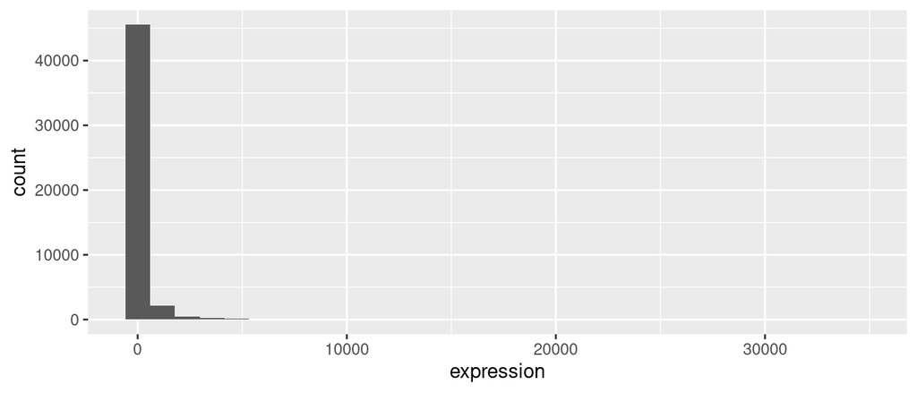

```r
ggplot(data=data.frame(expression=exprs(geo_data)[, 1]),
       aes(x=expression)) +
  geom_histogram()
```

Dataset is not normalized => Let’s do it!

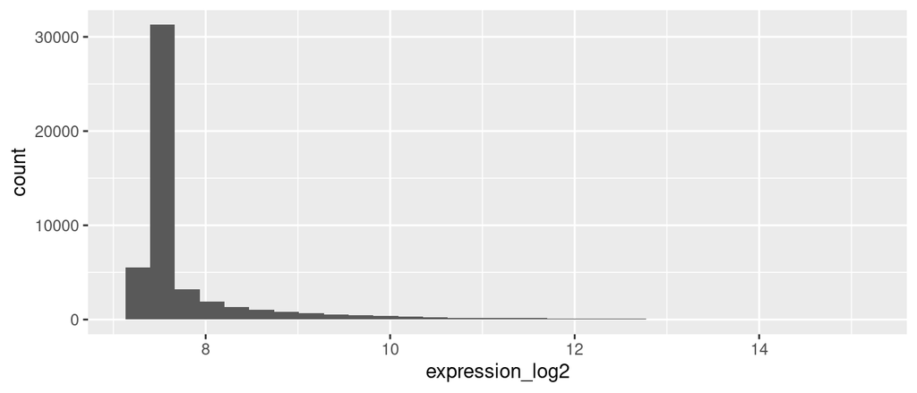

```r
ggplot(data=data.frame(expression_log2=log2(exprs(geo_data) [, 1])),
       aes(x=expression_log2)) +
  geom_histogram()
```

```r
min(exprs(geo_data))
```

```
## [1] 153.2313
```

Try quantile normalization:

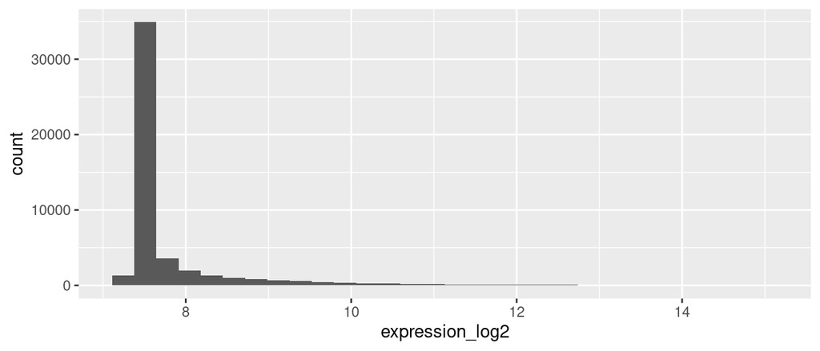

```r
ggplot(data=data.frame(expression_log2=normalizeBetweenArrays(log2(exprs(geo_data)+1), method="quantile") [, 1]),
       aes(x=expression_log2)) +
  geom_histogram()
```

Okayy, let’s do that:

```r
exprs(geo_data) <- normalizeBetweenArrays(log2(exprs(geo_data)+1), method="quantile")
twoSamples <- melt(exprs(geo_data[, 1:2]))
```

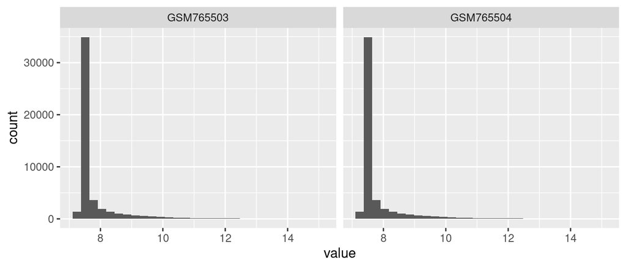

```r
ggplot(data=twoSamples, aes(x=value)) +
  facet_grid(~Var2) + geom_histogram()
```

Now distribution between 2 samples is tha same:) Good!

## From MA to genes

```r
geo_data <- geo_data[!grepl("///", fData(geo_data)$`Gene symbol`), ]
geo_data <- geo_data[fData(geo_data)$`Gene symbol` != "", ]

fData(geo_data)$mean_expression <- apply(exprs(geo_data), 1, mean)
geo_data <- geo_data[order(fData(geo_data)$mean_expression, decreasing = TRUE), ]
geo_data <- geo_data[!duplicated(fData(geo_data)$`Gene ID`), ]
geo_data <- geo_data[seq_len(12000), ]
dim(geo_data)
```

```
## Features  Samples
##    12000       46
```

## PCA

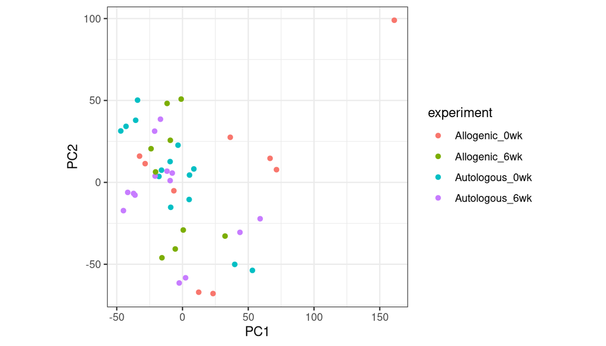

```r
pcas <- prcomp(t(exprs(geo_data)), scale. = T)
plotData <- cbind(pcas$x[, 1:2], pData(geo_data))
ggplot(plotData, aes(x=PC1, y=PC2, color=experiment)) +
  geom_point() + theme_bw() + theme(aspect.ratio = 1)
```

We have one outlier, lets get it and delete:

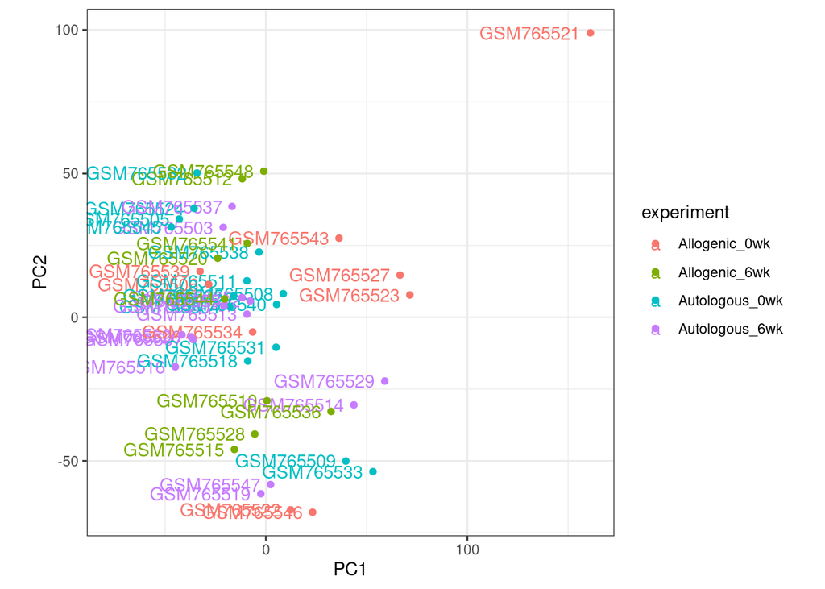

```r
ggplot(plotData, aes(x=PC1, y=PC2, color=experiment)) + geom_text(aes(label=rownames(plotData)), nudge_x = -30, nudge_y = 0) +
  geom_point() + theme_bw() + theme(aspect.ratio = 1)
```

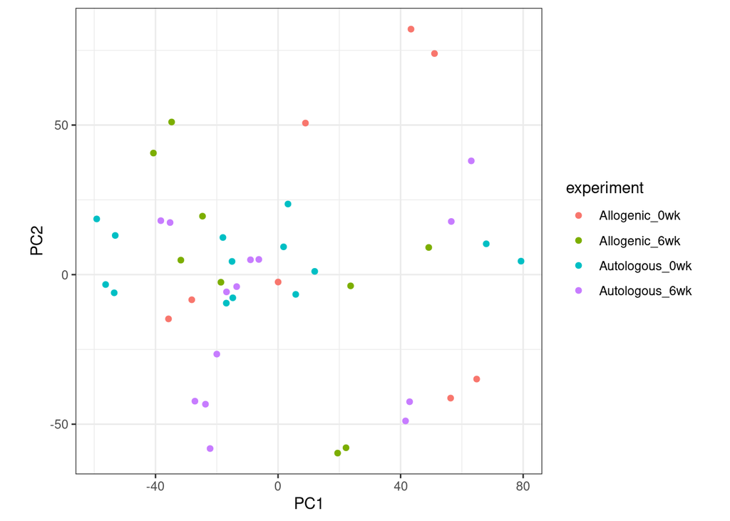

```r
geo_data <- geo_data[,pData(geo_data)$geo != "GSM765521"]
pcas <- prcomp(t(exprs(geo_data)), scale. = T)
plotData <- cbind(pcas$x[, 1:2], pData(geo_data))
ggplot(plotData, aes(x=PC1, y=PC2, color=experiment)) +
  geom_point() + theme_bw() + theme(aspect.ratio = 1)
```

Very nice!

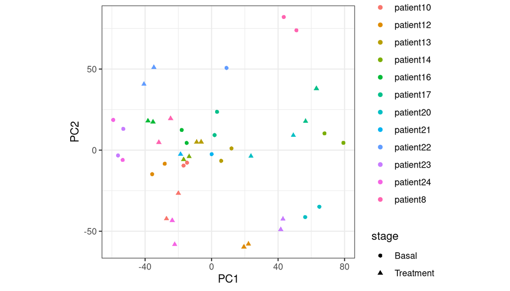

```r
pcas <- prcomp(t(exprs(geo_data)), scale. = T)
    plotData <- cbind(pcas$x[, 1:2], pData(geo_data))
    ggplot(plotData, aes(x=PC1, y=PC2, color=sample_id, shape = stage)) + geom_point() + theme_bw() + theme(aspect.ratio = 1)
```

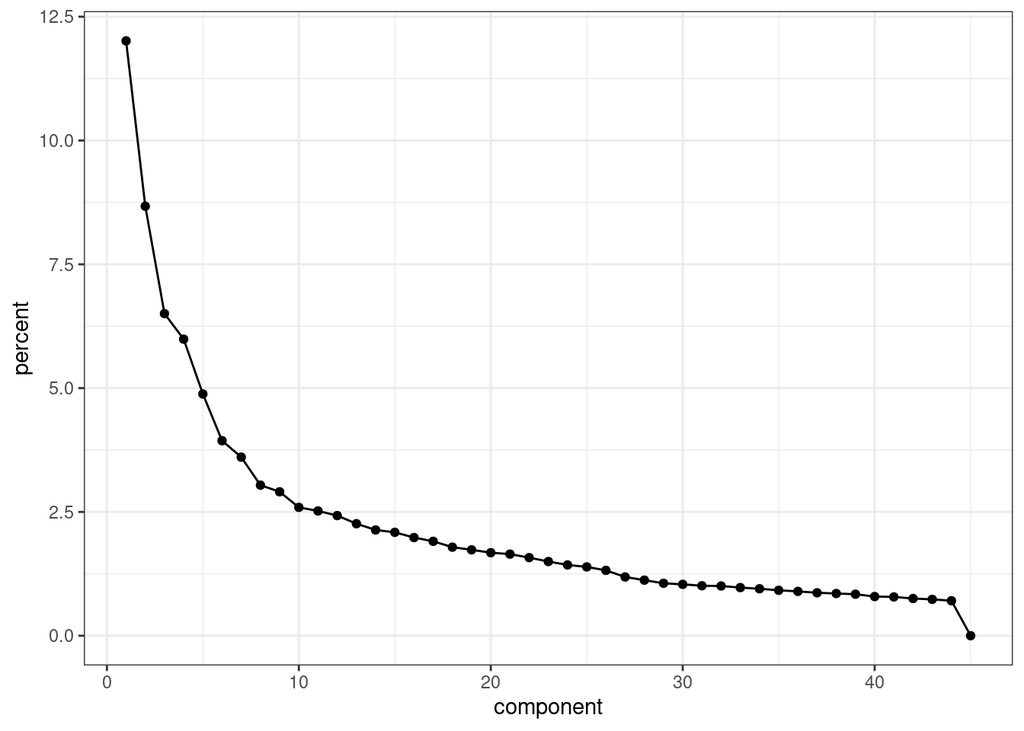

```r
variance <- pcas$sdev^2
variance <- variance / sum(variance)
ggplot(data=data.frame(component=1:45, percent=variance * 100),
       aes(x=component, y=percent)) +
  geom_point() + geom_line() + theme_bw()
```

Bad news! We can not divide them by autologous/allogenic or before treatment(baseline)/after treatment.

But it is divided well by specific human (and before treatment(baseline)/after treatment). That mean, that differences in specific people contribute more than differences in changing their microbiome.

And we have one outlier, BUT FIRST, batch normalization!

```r
batch <- pData(geo_data)$sample_id
modcombat <- model.matrix(~1, data=pData(geo_data))
combat_geo_data = ComBat(dat=exprs(geo_data), batch=batch, mod=modcombat)
```

```
## Found 14 genes with uniform expression within a single batch (all zeros); these will not be adjusted for batch.
```

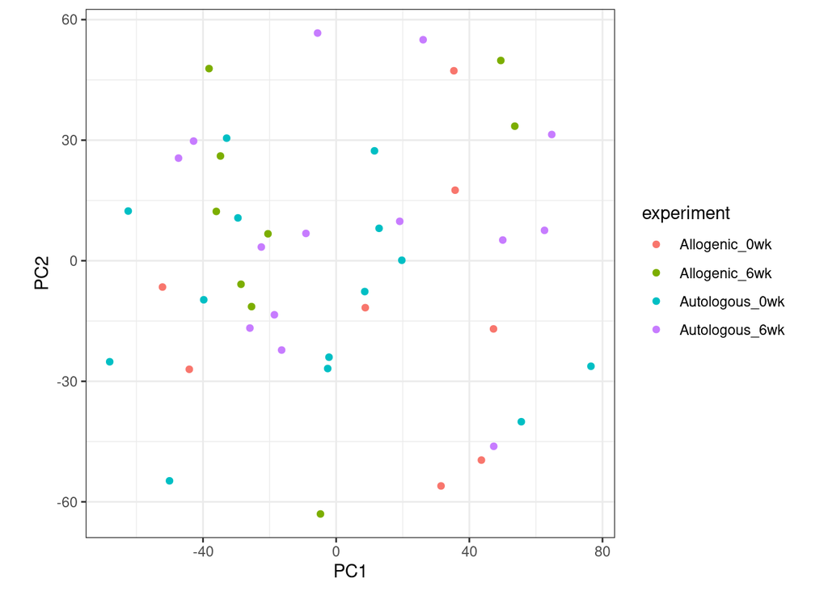

```r
pcas <- prcomp(t(combat_geo_data), scale. = T)
plotData <- cbind(pcas$x[, 1:2], pData(geo_data))
ggplot(plotData, aes(x=PC1, y=PC2, color=experiment)) +
  geom_point() + theme_bw() + theme(aspect.ratio = 1)
```

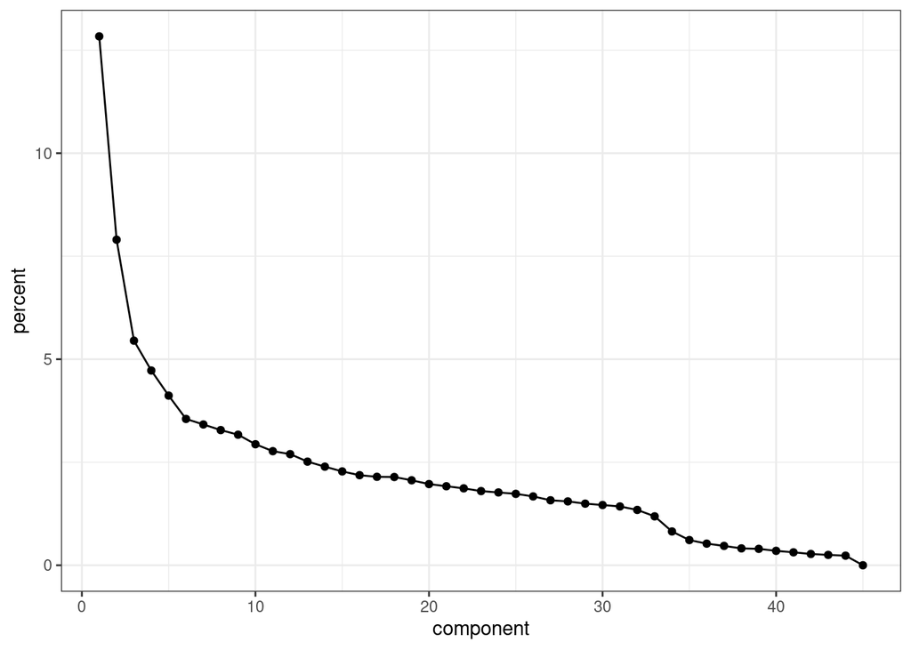

```r
variance <- pcas$sdev^2
variance <- variance / sum(variance)
ggplot(data=data.frame(component=1:45, percent=variance * 100),
       aes(x=component, y=percent)) +
  geom_point() + geom_line() + theme_bw()
```

A little better. Kostya said, we have to take `pData(geo_data)$sample_id` into account. Okayy, Let’s design experiment.

## Designing

One more time, I will take `experiment` and `sample_id` into aсcount, when I perform DE.

As I want to understand difference between 2 groups, I will make 2 comparisons: with treatment (allo) before/after, without treatment (auto) before/after,

#### Autologous (not changed (their own) microbiom)

```r
geo_auto <- geo_data[,pData(geo_data)$type == "Autologous"]
pData(geo_auto)
```

|  | title | geo | type | sample_id | disease | stage | description | experiment |
| --- | --- | --- | --- | --- | --- | --- | --- | --- |
| GSM765503 | Autologous_6wk (5370916043_A) | GSM765503 | Autologous | patient16 | Obese | Treatment | 5370916043_A | Autologous_6wk |
| GSM765504 | Autologous_0wk (5370916043_B) | GSM765504 | Autologous | patient10 | Obese | Basal | 5370916043_B | Autologous_0wk |
| GSM765505 | Autologous_0wk (5370916043_C) | GSM765505 | Autologous | patient23 | Obese | Basal | 5370916043_C | Autologous_0wk |
| GSM765507 | Autologous_6wk (5370916043_E) | GSM765507 | Autologous | patient10 | Obese | Treatment | 5370916043_E | Autologous_6wk |
| GSM765508 | Autologous_0wk (5370916043_F) | GSM765508 | Autologous | patient17 | Obese | Basal | 5370916043_F | Autologous_0wk |
| GSM765509 | Autologous_0wk (5370916043_G) | GSM765509 | Autologous | patient14 | Obese | Basal | 5370916043_G | Autologous_0wk |
| GSM765511 | Autologous_0wk (5370916043_I) | GSM765511 | Autologous | patient16 | Obese | Basal | 5370916043_I | Autologous_0wk |
| GSM765513 | Autologous_6wk (5370916043_K) | GSM765513 | Autologous | patient13 | Obese | Treatment | 5370916043_K | Autologous_6wk |
| GSM765514 | Autologous_6wk (5370916043_L) | GSM765514 | Autologous | patient17 | Obese | Treatment | 5370916043_L | Autologous_6wk |
| GSM765516 | Autologous_6wk (5370916047_C) | GSM765516 | Autologous | patient24 | Obese | Treatment | 5370916047_C | Autologous_6wk |

[output cut: 18 more lines]

```r
auto_model <- model.matrix(~0 + experiment + sample_id, data = pData(geo_auto))
colnames(auto_model)
```

```
## [1] "experimentAutologous_0wk" "experimentAutologous_6wk"
## [3] "sample_idpatient13"       "sample_idpatient14"
## [5] "sample_idpatient16"       "sample_idpatient17"
## [7] "sample_idpatient23"       "sample_idpatient24"
```

```r
colnames(auto_model) <- c("auto_0", "auto_6", "p13", "p14", "p16", "p17", "p23", "p24")
```

```r
fit <- lmFit(geo_auto, auto_model)
fit2 <- contrasts.fit(fit, makeContrasts(auto_6 - auto_0, levels=auto_model))
fit2 <- eBayes(fit2, trend = T)
de <- topTable(fit2, adjust.method="BH", number=Inf, sort.by = "P")
head(de)
```

|  | ID | Gene.symbol | Gene.ID | mean_expression | logFC | AveExpr | t | P.Value | adj.P.Val | B |
| --- | --- | --- | --- | --- | --- | --- | --- | --- | --- | --- |
| ILMN_1711015 | ILMN_1711015 | CRYAA | 1409 | 8.235309 | 0.5903602 | 8.346525 | 7.309365 | 3.663094e-08 | 0.0004395713 | 8.095576 |
| ILMN_1794638 | ILMN_1794638 | VIP | 7432 | 8.624552 | -0.9116566 | 8.767207 | -6.033644 | 1.226688e-06 | 0.0073601285 | 5.122630 |
| ILMN_1767842 | ILMN_1767842 | SLC17A8 | 246213 | 7.933852 | 0.1961719 | 7.984355 | 5.169300 | 1.410919e-05 | 0.0439903535 | 3.010159 |
| ILMN_1717261 | ILMN_1717261 | HLA-DRB3 | 3125 | 9.414537 | 0.3381374 | 9.549954 | 5.035046 | 2.064629e-05 | 0.0439903535 | 2.678584 |
| ILMN_2316236 | ILMN_2316236 | HOPX | 84525 | 8.838025 | -0.3585909 | 8.740813 | -4.935971 | 2.733970e-05 | 0.0439903535 | 2.433721 |
| ILMN_1807291 | ILMN_1807291 | CYP1A1 | 1543 | 8.193451 | 0.4774794 | 8.110764 | 4.925762 | 2.814197e-05 | 0.0439903535 | 2.408488 |

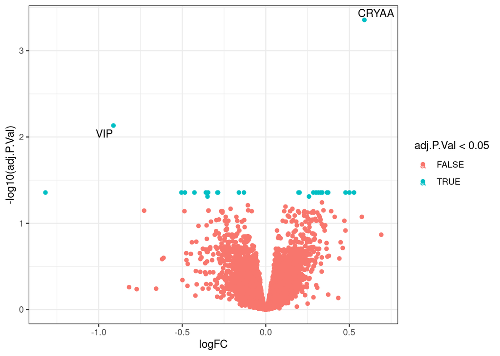

```r
ggplot(de, aes(x=logFC, y=-log10(adj.P.Val), color=adj.P.Val < 0.05)) +
  geom_point() + theme_bw() +
  geom_text_repel(data=de %>% dplyr::filter(adj.P.Val < 0.01), aes(label=Gene.symbol, color=NULL))
```

#### Allogenic (changed microbiom)

```r
geo_allo <- geo_data[,pData(geo_data)$type == "Allogenic"]
pData(geo_allo)
```

|  | title | geo | type | sample_id | disease | stage | description | experiment |
| --- | --- | --- | --- | --- | --- | --- | --- | --- |
| GSM765506 | Allogenic_0wk (5370916043_D) | GSM765506 | Allogenic | patient12 | Obese | Basal | 5370916043_D | Allogenic_0wk |
| GSM765510 | Allogenic_6wk (5370916043_H) | GSM765510 | Allogenic | patient20 | Obese | Treatment | 5370916043_H | Allogenic_6wk |
| GSM765512 | Allogenic_6wk (5370916043_J) | GSM765512 | Allogenic | patient22 | Obese | Treatment | 5370916043_J | Allogenic_6wk |
| GSM765515 | Allogenic_6wk (5370916047_A) | GSM765515 | Allogenic | patient12 | Obese | Treatment | 5370916047_A | Allogenic_6wk |
| GSM765520 | Allogenic_6wk (5370916047_H) | GSM765520 | Allogenic | patient8 | Obese | Treatment | 5370916047_H | Allogenic_6wk |
| GSM765522 | Allogenic_0wk (5370916047_J) | GSM765522 | Allogenic | patient20 | Obese | Basal | 5370916047_J | Allogenic_0wk |
| GSM765523 | Allogenic_0wk (5370916047_K) | GSM765523 | Allogenic | patient8 | Obese | Basal | 5370916047_K | Allogenic_0wk |
| GSM765527 | Allogenic_0wk (5375611005_C) | GSM765527 | Allogenic | patient8 | Obese | Basal | 5375611005_C | Allogenic_0wk |
| GSM765528 | Allogenic_6wk (5375611005_D) | GSM765528 | Allogenic | patient12 | Obese | Treatment | 5375611005_D | Allogenic_6wk |
| GSM765534 | Allogenic_0wk (5375611005_J) | GSM765534 | Allogenic | patient21 | Obese | Basal | 5375611005_J | Allogenic_0wk |

[output cut: 7 more lines]

```r
allo_model <- model.matrix(~0 + experiment + sample_id, data = pData(geo_allo))
colnames(allo_model)
```

```
## [1] "experimentAllogenic_0wk" "experimentAllogenic_6wk"
## [3] "sample_idpatient20"      "sample_idpatient21"
## [5] "sample_idpatient22"      "sample_idpatient8"
```

```r
colnames(allo_model) <- c("allo_0", "allo_6", "p20", "p21", "p22", "p8")
```

```r
fit <- lmFit(geo_allo, allo_model)
fit2 <- contrasts.fit(fit, makeContrasts(allo_6 - allo_0, levels=allo_model))
fit2 <- eBayes(fit2, trend = T)
de <- topTable(fit2, adjust.method="BH", number=Inf, sort.by = "P")
head(de)
```

|  | ID | Gene.symbol | Gene.ID | mean_expression | logFC | AveExpr | t | P.Value | adj.P.Val | B |
| --- | --- | --- | --- | --- | --- | --- | --- | --- | --- | --- |
| ILMN_1699421 | ILMN_1699421 | ANXA10 | 11199 | 9.859239 | -1.6578939 | 10.091278 | -8.360257 | 4.953523e-08 | 0.0005944227 | 7.160222 |
| ILMN_2364022 | ILMN_2364022 | SLC16A3 | 9123 | 9.286563 | -0.4960546 | 9.073093 | -5.253909 | 3.586991e-05 | 0.1344483542 | 2.101481 |
| ILMN_2174437 | ILMN_2174437 | CIDEC | 63924 | 12.752476 | -0.6906466 | 12.565765 | -5.023987 | 6.108719e-05 | 0.1344483542 | 1.664881 |
| ILMN_1809894 | ILMN_1809894 | TMEM117 | 84216 | 8.026866 | 0.2922887 | 8.008807 | 4.994681 | 6.539676e-05 | 0.1344483542 | 1.608761 |
| ILMN_1683694 | ILMN_1683694 | SLC6A4 | 6532 | 8.662989 | 0.4118177 | 8.613675 | 4.987828 | 6.644825e-05 | 0.1344483542 | 1.595623 |
| ILMN_1682775 | ILMN_1682775 | EDN1 | 1906 | 8.314249 | 0.3848192 | 8.354427 | 4.944780 | 7.345685e-05 | 0.1344483542 | 1.512971 |

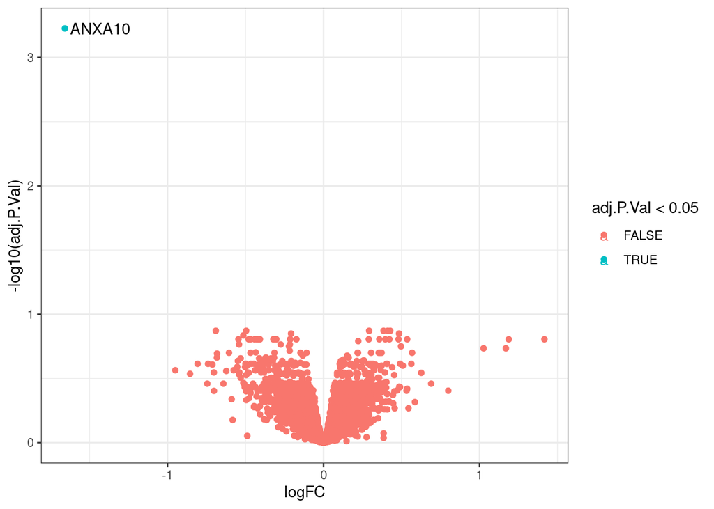

```r
ggplot(de, aes(x=logFC, y=-log10(adj.P.Val), color=adj.P.Val < 0.05)) +
  geom_point() + theme_bw() +
  geom_text_repel(data=de %>% dplyr::filter(adj.P.Val < 0.05), aes(label=Gene.symbol, color=NULL))
```

Bad news, we can’t see almost any changes.

### Without splitting

Let’s try without splitting to 2 datasets:

```r
full_model <- model.matrix(~0 + experiment + sample_id, data = pData(geo_data))
colnames(full_model)
```

```
##  [1] "experimentAllogenic_0wk"  "experimentAllogenic_6wk"
##  [3] "experimentAutologous_0wk" "experimentAutologous_6wk"
##  [5] "sample_idpatient12"       "sample_idpatient13"
##  [7] "sample_idpatient14"       "sample_idpatient16"
##  [9] "sample_idpatient17"       "sample_idpatient20"
## [11] "sample_idpatient21"       "sample_idpatient22"
## [13] "sample_idpatient23"       "sample_idpatient24"
## [15] "sample_idpatient8"
```

```r
colnames(full_model) <- c("allo_0", "allo_6", "auto_0", "auto_6", "p12", "p13", "p14", "p16", "p17", "p20", "p21", "p22", "p23", "p24", "p8")
```

#### Allogenic

```r
fit <- lmFit(geo_data, full_model)
```

```
## Coefficients not estimable: p8
```

```r
fit2 <- contrasts.fit(fit, makeContrasts(allo_6 - allo_0, levels=full_model))
fit2 <- eBayes(fit2, trend = T)
de_al <- topTable(fit2, adjust.method="BH", number=Inf, sort.by = "P")
head(de_al)
```

|  | ID | Gene.symbol | Gene.ID | mean_expression | logFC | AveExpr | t | P.Value | adj.P.Val | B |
| --- | --- | --- | --- | --- | --- | --- | --- | --- | --- | --- |
| ILMN_1779558 | ILMN_1779558 | GAS6 | 2621 | 9.622269 | 0.4842644 | 9.610954 | 5.300636 | 4.147455e-06 | 0.01557077 | 4.047210 |
| ILMN_2364022 | ILMN_2364022 | SLC16A3 | 9123 | 9.286563 | -0.4960546 | 9.271571 | -5.278344 | 4.459788e-06 | 0.01557077 | 3.983633 |
| ILMN_1682775 | ILMN_1682775 | EDN1 | 1906 | 8.314249 | 0.3848192 | 8.329698 | 5.253295 | 4.838653e-06 | 0.01557077 | 3.912225 |
| ILMN_2174437 | ILMN_2174437 | CIDEC | 63924 | 12.752476 | -0.6906466 | 12.760754 | -5.231732 | 5.190258e-06 | 0.01557077 | 3.850783 |
| ILMN_1699421 | ILMN_1699421 | ANXA10 | 11199 | 9.859239 | -1.6578939 | 9.777357 | -4.900314 | 1.516481e-05 | 0.03313555 | 2.910764 |
| ILMN_1785284 | ILMN_1785284 | ALDH6A1 | 4329 | 9.311642 | 0.4224087 | 9.330942 | 4.872785 | 1.656777e-05 | 0.03313555 | 2.833135 |

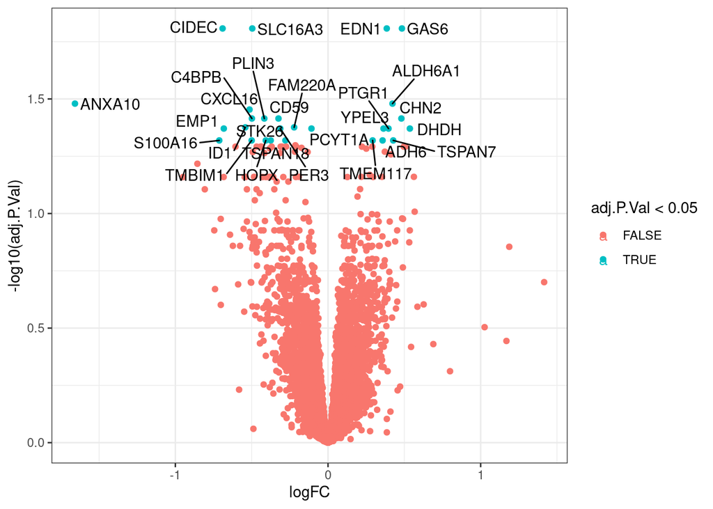

```r
ggplot(de_al, aes(x=logFC, y=-log10(adj.P.Val), color=adj.P.Val < 0.05)) +
  geom_point() + theme_bw() +
  geom_text_repel(data=de_al %>% dplyr::filter(adj.P.Val < 0.05), aes(label=Gene.symbol, color=NULL))
```

#### Autologous

```r
fit <- lmFit(geo_data, full_model)
```

```
## Coefficients not estimable: p8
```

```r
fit2 <- contrasts.fit(fit, makeContrasts(auto_6 - auto_0, levels=full_model))
fit2 <- eBayes(fit2, trend = T)
de_au <- topTable(fit2, adjust.method="BH", number=Inf, sort.by = "P")
head(de_au)
```

|  | ID | Gene.symbol | Gene.ID | mean_expression | logFC | AveExpr | t | P.Value | adj.P.Val | B |
| --- | --- | --- | --- | --- | --- | --- | --- | --- | --- | --- |
| ILMN_1711015 | ILMN_1711015 | CRYAA | 1409 | 8.235309 | 0.5903602 | 8.254220 | 8.006504 | 6.097421e-10 | 7.316905e-06 | 11.629443 |
| ILMN_1794638 | ILMN_1794638 | VIP | 7432 | 8.624552 | -0.9116566 | 8.625175 | -5.328409 | 3.788529e-06 | 2.273117e-02 | 4.123082 |
| ILMN_1699421 | ILMN_1699421 | ANXA10 | 11199 | 9.859239 | -1.3185581 | 9.777357 | -5.051508 | 9.312266e-06 | 2.705495e-02 | 3.335736 |
| ILMN_1676563 | ILMN_1676563 | HTRA1 | 5654 | 8.415108 | -0.2852111 | 8.408186 | -4.959782 | 1.252221e-05 | 2.705495e-02 | 3.076202 |
| ILMN_1767842 | ILMN_1767842 | SLC17A8 | 246213 | 7.933852 | 0.1961719 | 7.944990 | 4.904565 | 1.495885e-05 | 2.705495e-02 | 2.920355 |
| ILMN_2316236 | ILMN_2316236 | HOPX | 84525 | 8.838025 | -0.3585909 | 8.838013 | -4.895800 | 1.538652e-05 | 2.705495e-02 | 2.895643 |

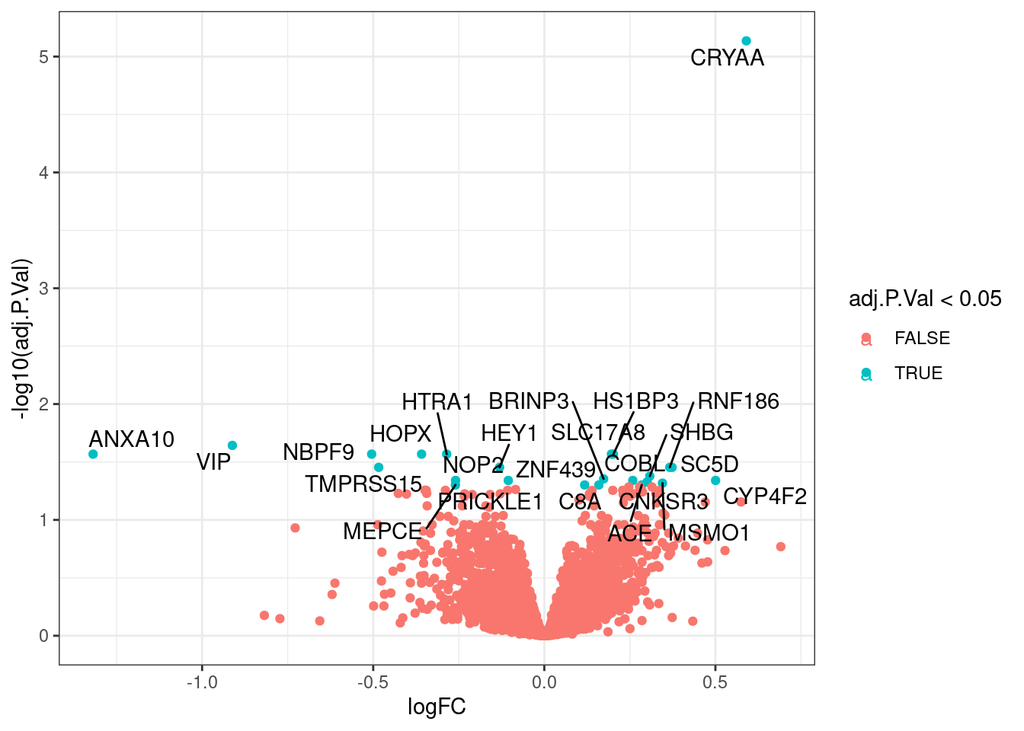

```r
ggplot(de_au, aes(x=logFC, y=-log10(adj.P.Val), color=adj.P.Val < 0.05)) +
  geom_point() + theme_bw() +
  geom_text_repel(data=de_au %>% dplyr::filter(adj.P.Val < 0.05), aes(label=Gene.symbol, color=NULL))
```

Wow, I think that’s cool:

Good!

## Pathways

Find affected pathways allogenic patients using `fgsea`

```r
load("keggSymbolHuman.rdata")
stats <- de_al$t
names(stats) <- de_al$Gene.symbol
fgseaResults <- fgseaMultilevel(keggSymbolHuman, stats, minSize = 15, maxSize = 500)
# head(fgseaResults, 5)

topPathwaysUp <- fgseaResults[ES > 0, ][head(order(pval), n=5), pathway]
topPathwaysDown <- fgseaResults[ES < 0, ][head(order(pval), n=5), pathway]
topPathways <- c(topPathwaysUp, rev(topPathwaysDown))
topPathways
```

```
##  [1] "Drug metabolism - cytochrome P450 - Homo sapiens (human)"
##  [2] "Metabolism of xenobiotics by cytochrome P450 - Homo sapiens (human)"
##  [3] "Valine, leucine and isoleucine degradation - Homo sapiens (human)"
##  [4] "Ribosome - Homo sapiens (human)"
##  [5] "Glutathione metabolism - Homo sapiens (human)"
##  [6] "Tight junction - Homo sapiens (human)"
##  [7] "Focal adhesion - Homo sapiens (human)"
##  [8] "Bacterial invasion of epithelial cells - Homo sapiens (human)"
##  [9] "Pathogenic Escherichia coli infection - Homo sapiens (human)"
## [10] "MAPK signaling pathway - Homo sapiens (human)"
```

```r
# plotGseaTable(keggSymbolHuman[topPathways], stats, fgseaResults, gseaParam = 0.5)
```

```r
load("keggSymbolHuman.rdata")
stats <- de_au$t
names(stats) <- de_au$Gene.symbol
fgseaResults <- fgseaMultilevel(keggSymbolHuman, stats, minSize = 15, maxSize = 500)
# head(fgseaResults, 5)

topPathwaysUp <- fgseaResults[ES > 0, ][head(order(pval), n=5), pathway]
topPathwaysDown <- fgseaResults[ES < 0, ][head(order(pval), n=5), pathway]
topPathways <- c(topPathwaysUp, rev(topPathwaysDown))
```

## Analysis

Back to the investigation.

In patients with microbiota dysbiosis, top-1 and 2 upregulated pathways are `Drug metabolism`, `Metabolism of xenobiotics` - may be foreign substances had some drugs to which the body has no resistance.

That’s it!

(Kostya, sorry for my “biology”:))